# For each tower, how do annual mean air temperature and annual precipitation compare with its WorldClim 1970–2000 normal?

Author

Affiliation

Paul Eberle

Student Number 30

Published

November 26, 2026

Project fork and source: Pau-Rico/datascience_env_monit.

# E1. Question and hypothesis

**Question.** For each tower, how do annual mean air temperature and annual precipitation compare with its WorldClim 1970–2000 normal?

**Hypothesis.** I expect annual temperatures to be mostly above the 1970–2000 normal. I expect precipitation to vary between towers and years. Recent warming may raise temperatures above the older normal. Precipitation may change more from year to year and from site to site.

The five towers are in different regions and ecosystems. They are useful for comparing sites, but they do not represent all climates. Their records cover different periods, so the sites are not compared over the same years.

# E2. Data

The analysis uses FLUXNET daily data and two Block 5 datasets: WorldClim and ERA5-Land.

| Dataset | Variables used | Spatial resolution | Time resolution and period | Download date | Script and changes | Citation |
| --- | --- | --- | --- | --- | --- | --- |
| FLUXNET | `TA_F` (air temperature), `TA_F_QC` (temperature QC), `P_F` (precipitation), `P_F_QC` (precipitation QC) | Tower measurement, approximate flux footprint 100 m–1 km | Daily, 1999–2025. Site periods are in Table Table 1 | 20 Nov 2026 | Existing `FLUXMET_DD` files in `data/raw`. QC fields were read directly because `09_merge.py` omits them | Site data-product citations and acknowledgement in E6, Pastorello et al. (2020) |
| WorldClim 2.1 | BIO1 (temperature normal, °C), BIO12 (precipitation normal, mm) | 5 arc-minutes, approximately 9 km | 1970–2000 climate normals | 20 Nov 2026 | `scripts/block5/02_worldclim.py`, 5′ resolution and nearest-cell sampling | Fick & Hijmans (2017) |
| ERA5-Land | `t2m_C` (2 m air temperature) | 0.1°, approximately 9 km | Daily means derived from hourly data. Last available 8–10 tower years, listed in Table Table 1 | 20 and 25 Nov 2026 | `scripts/block5/01_era5land.py`, 10-year setting. No analysis settings changed | Muñoz-Sabater et al. (2021) |

ERA5-Land daily means use UTC days. The downloaded ERA5-Land files have no precipitation values, so I use FLUXNET for precipitation.

Table Table 1 describes the two gridded datasets at each tower and the available FLUXNET record. A blank ERA5-Land period means that the file had no valid daily 2 m temperature values for that tower.

```python
coverage = (
    annual.groupby("site_id", as_index=False)
    .agg(
        flux_first_year=("year", "min"),
        flux_last_year=("year", "max"),
        flux_years=("year", "nunique"),
        flux_days=("n_days", "sum"),
        ta_missing_days=("ta_missing_days", "sum"),
        precip_missing_days=("precip_missing_days", "sum"),
        mean_TA_QC=("ta_qc_fraction", "mean"),
        mean_P_QC=("precip_qc_fraction", "mean"),
    )
)

valid_era = annual.dropna(subset=["era5_anomaly_C"])
era_coverage = (
    valid_era.groupby("site_id", as_index=False)
    .agg(
        era5_first_year=("year", "min"),
        era5_last_year=("year", "max"),
        era5_years=("year", "nunique"),
        era5_valid_days=("era5_days", "sum"),
        mean_era5_temp_C=("era5_mean_C", "mean"),
        mean_era5_departure_C=("era5_anomaly_C", "mean"),
    )
)
site_summary = (
    worldclim.merge(coverage, on="site_id", how="left", validate="one_to_one")
    .merge(era_coverage, on="site_id", how="left", validate="one_to_one")
)
site_summary["era5_years"] = site_summary["era5_years"].fillna(0).astype(int)
site_summary["era5_valid_days"] = site_summary["era5_valid_days"].fillna(0).astype(int)

site_summary[
    [
        "site_id",
        "BIO1",
        "BIO12",
        "flux_first_year",
        "flux_last_year",
        "flux_years",
        "flux_days",
        "ta_missing_days",
        "precip_missing_days",
        "mean_TA_QC",
        "mean_P_QC",
        "era5_first_year",
        "era5_last_year",
        "era5_years",
        "era5_valid_days",
        "mean_era5_temp_C",
        "mean_era5_departure_C",
    ]
].round(2)
```

Table 1: WorldClim normals and data coverage at the five selected towers.

|  | site_id | BIO1 | BIO12 | flux_first_year | flux_last_year | flux_years | flux_days | ta_missing_days | precip_missing_days | mean_TA_QC | mean_P_QC | era5_first_year | era5_last_year | era5_years | era5_valid_days | mean_era5_temp_C | mean_era5_departure_C |
| --- | --- | --- | --- | --- | --- | --- | --- | --- | --- | --- | --- | --- | --- | --- | --- | --- | --- |
| 0 | JP-Ynf | 21.72 | 2136.0 | 2013 | 2022 | 10 | 3652 | 0 | 0 | 0.87 | 0.00 | NaN | NaN | 0 | 0 | NaN | NaN |
| 1 | BE-Bra | 10.31 | 807.0 | 1999 | 2025 | 27 | 9862 | 0 | 0 | 0.89 | 0.90 | 2015.0 | 2024.0 | 10 | 3653 | 11.63 | 1.32 |
| 2 | CH-Oe1 | 8.55 | 1222.0 | 2002 | 2011 | 10 | 3652 | 0 | 0 | 1.00 | 1.00 | 2002.0 | 2011.0 | 10 | 3652 | 9.09 | 0.55 |
| 3 | US-MN2 | 6.05 | 599.0 | 2017 | 2024 | 8 | 2922 | 0 | 0 | 0.94 | 0.94 | 2017.0 | 2024.0 | 8 | 2922 | 7.40 | 1.35 |
| 4 | AU-TTE | 22.87 | 260.0 | 2012 | 2025 | 14 | 5114 | 0 | 0 | 0.66 | 0.60 | 2016.0 | 2025.0 | 10 | 3653 | 23.62 | 0.76 |

Each tower has its own WorldClim normals. The WorldClim file contains all five towers. ERA5-Land has complete daily data for its available periods at AU-TTE, BE-Bra, CH-Oe1, and US-MN2. The JP-Ynf file has 3,652 dates, but all `t2m_C` values are missing. I leave them missing and do not fill them from another dataset or tower.

# E3. Methods

**Download and extraction.** WorldClim BIO1 and BIO12 were sampled from the nearest 5′ grid cells using the tower coordinates in EPSG:4326. ERA5-Land daily data were requested from the nearest 0.1° grid cell for the last 10 available years, using coordinates rounded to three decimal places. The analysis settings were unchanged, and the only local script edit replaced the example CDS-key text with a placeholder.

**Flux preparation and quality control.** I read the daily `FLUXMET_DD` files from the five original ZIP files and treated `-9999` as missing. Annual air temperature is the mean of daily `TA_F` (°C). Annual precipitation is the sum of daily `P_F` (mm). For each year, I calculated the mean daily `TA_F_QC` and `P_F_QC` values. The merge script does not include these QC columns, so I read them from the original daily files. The data contain 25,202 tower-days and 69 complete site-years. There are no missing `TA_F` or `P_F` values.

The first calculation uses all years, regardless of QC. The second keeps years with a mean annual QC fraction of at least 0.90. This cutoff is my choice, not an official FLUXNET pass/fail rule. QC fractions describe the quality of gap-filled data. A year that passes the cutoff can still include gap-filled data. I apply the cutoff separately to temperature and precipitation.

**Alignment and analysis.** I joined annual FLUXNET values to the WorldClim BIO1 and BIO12 values for each tower, using `site_id` and year. Temperature departure is `annual mean TA_F − BIO1`. Precipitation departure is `annual sum P_F − BIO12`. Positive values mean warmer or wetter conditions than that tower’s normal. I averaged ERA5-Land daily `t2m_C` by calendar year (UTC) and compared it with BIO1. Missing values stayed as `NA`.

The pooled median gives each site-year equal weight. Towers with longer records therefore have more influence. Annual values from one tower may not be independent of each other.

# E4. Results

The temperature figure compares annual FLUXNET and ERA5-Land departures from each tower’s WorldClim normal. The precipitation figure shows FLUXNET departures from WorldClim BIO12. The zero line means the value equals the WorldClim normal. FLUXNET years below the 0.90 QC cutoff are shown with transparent points and dashed lines. All years remain visible.

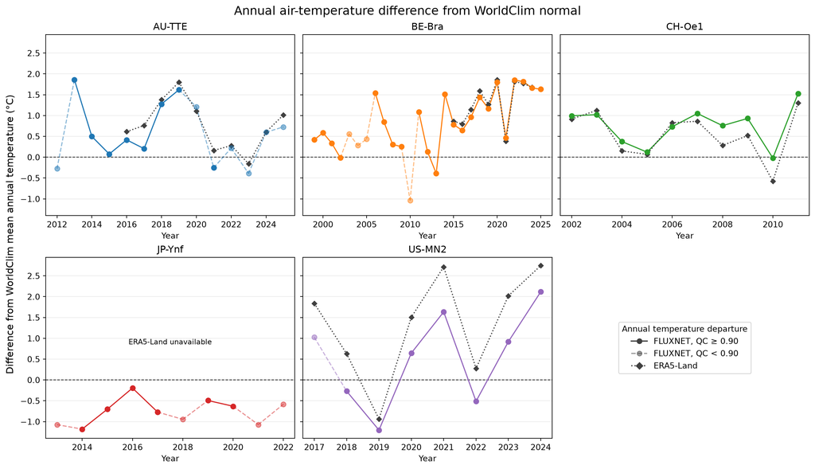

Annual mean air-temperature departure from each tower’s WorldClim BIO1 normal. Circles are FLUXNET annual values and diamonds are ERA5-Land annual values. The zero line indicates the site-specific normal. FLUXNET years with annual QC below 0.90 are semi-transparent and dashed. ERA5-Land is unavailable for JP-Ynf.

```python
fig, axes = plt.subplots(2, 3, figsize=(14, 8), sharey=True, constrained_layout=True)
for ax, site_id in zip(axes.flat, SITE_IDS):
    site = annual[annual["site_id"] == site_id].sort_values("year")
    for i in range(len(site) - 1):
        first = site.iloc[i]
        second = site.iloc[i + 1]
        low_qc = (
            first["ta_qc_fraction"] < QC_THRESHOLD
            or second["ta_qc_fraction"] < QC_THRESHOLD
        )
        ax.plot(
            [first["year"], second["year"]],
            [first["temp_anomaly_C"], second["temp_anomaly_C"]],
            color=site_colors[site_id],
            linewidth=1.35,
            linestyle="--" if low_qc else "-",
            alpha=0.5 if low_qc else 1,
            zorder=2,
        )
    good = site[site["ta_qc_fraction"] >= QC_THRESHOLD]
    low = site[site["ta_qc_fraction"] < QC_THRESHOLD]
    ax.scatter(
        good["year"], good["temp_anomaly_C"], color=site_colors[site_id],
        edgecolor=site_colors[site_id], s=38, zorder=4
    )
    ax.scatter(
        low["year"], low["temp_anomaly_C"], color=site_colors[site_id],
        edgecolor=site_colors[site_id], alpha=0.5, s=38, zorder=4
    )
    era = site.dropna(subset=["era5_anomaly_C"])
    if not era.empty:
        ax.plot(
            era["year"], era["era5_anomaly_C"], color="0.25",
            linestyle=":", linewidth=1.4, marker="D", markersize=4.5, zorder=3
        )
    else:
        ax.text(
            0.5, 0.53, "ERA5-Land unavailable", transform=ax.transAxes,
            ha="center", va="center", fontsize=9
        )
    ax.axhline(0, color="black", linewidth=0.9, linestyle="--", zorder=1)
    ax.set_title(site_id)
    ax.set_xlabel("Year")
    ax.grid(axis="y", alpha=0.25)

legend_ax = axes.flat[5]
legend_ax.axis("off")
legend_ax.legend(
    handles=[
        Line2D([0], [0], color="0.25", marker="o", linestyle="-",
               label="FLUXNET, QC ≥ 0.90"),
        Line2D([0], [0], color="0.25", marker="o", linestyle="--", alpha=0.5,
               label="FLUXNET, QC < 0.90"),
        Line2D([0], [0], color="0.25", marker="D", linestyle=":",
               label="ERA5-Land"),
    ],
    loc="center",
    title="Annual temperature departure",
)
fig.supylabel("Difference from WorldClim mean annual temperature (°C)")
fig.suptitle("Annual air-temperature difference from WorldClim normal", fontsize=15)
plt.show()
```

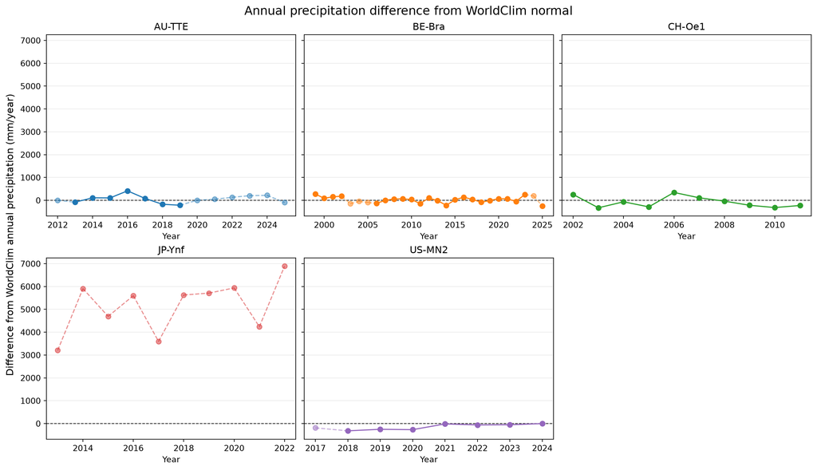

Annual FLUXNET precipitation departure from each tower’s WorldClim BIO12 normal. The zero line indicates the site-specific normal. Years with annual P_F_QC below 0.90 are semi-transparent and connected with dashed segments. JP-Ynf precipitation values are shown but have P_F_QC = 0 in every year.

```python
fig, axes = plt.subplots(2, 3, figsize=(14, 8), sharey=True, constrained_layout=True)
for ax, site_id in zip(axes.flat, SITE_IDS):
    site = annual[annual["site_id"] == site_id].sort_values("year")
    for i in range(len(site) - 1):
        first = site.iloc[i]
        second = site.iloc[i + 1]
        low_qc = (
            first["precip_qc_fraction"] < QC_THRESHOLD
            or second["precip_qc_fraction"] < QC_THRESHOLD
        )
        ax.plot(
            [first["year"], second["year"]],
            [first["precip_anomaly_mm"], second["precip_anomaly_mm"]],
            color=site_colors[site_id],
            linewidth=1.35,
            linestyle="--" if low_qc else "-",
            alpha=0.5 if low_qc else 1,
            zorder=2,
        )
    good = site[site["precip_qc_fraction"] >= QC_THRESHOLD]
    low = site[site["precip_qc_fraction"] < QC_THRESHOLD]
    ax.scatter(
        good["year"], good["precip_anomaly_mm"], color=site_colors[site_id],
        edgecolor=site_colors[site_id], s=38, zorder=4
    )
    ax.scatter(
        low["year"], low["precip_anomaly_mm"], color=site_colors[site_id],
        edgecolor=site_colors[site_id], alpha=0.5, s=38, zorder=4
    )
    ax.axhline(0, color="black", linewidth=0.9, linestyle="--", zorder=1)
    ax.set_title(site_id)
    ax.set_xlabel("Year")
    ax.grid(axis="y", alpha=0.25)

axes.flat[5].axis("off")
fig.supylabel("Difference from WorldClim annual precipitation (mm/year)")
fig.suptitle("Annual precipitation difference from WorldClim normal", fontsize=15)
plt.show()
```

The table shows medians and means of annual departures. It includes all years and a second calculation with annual QC ≥ 0.90.

```python
summary_rows = []
for variable, value_col, qc_col in [
    ("Temperature (°C)", "temp_anomaly_C", "ta_qc_fraction"),
    ("Precipitation (mm/year)", "precip_anomaly_mm", "precip_qc_fraction"),
]:
    for label, subset in [
        ("No QC filter", annual),
        ("Annual QC ≥ 0.90", annual[annual[qc_col] >= QC_THRESHOLD]),
    ]:
        valid = subset.dropna(subset=[value_col])
        summary_rows.append(
            {
                "Variable": variable,
                "Version": label,
                "Site-years (n)": len(valid),
                "Towers (n)": valid["site_id"].nunique(),
                "Pooled mean": valid[value_col].mean(),
                "Pooled median": valid[value_col].median(),
            }
        )
summary_table = pd.DataFrame(summary_rows)
summary_table.round(2)
```

Annual climate departures from WorldClim, with unfiltered and QC ≥ 0.90 summaries.

|  | Variable | Version | Site-years (n) | Towers (n) | Pooled mean | Pooled median |
| --- | --- | --- | --- | --- | --- | --- |
| 0 | Temperature (°C) | No QC filter | 69 | 5 | 0.48 | 0.50 |
| 1 | Temperature (°C) | Annual QC ≥ 0.90 | 54 | 5 | 0.62 | 0.64 |
| 2 | Precipitation (mm/year) | No QC filter | 69 | 5 | 736.65 | 34.91 |
| 3 | Precipitation (mm/year) | Annual QC ≥ 0.90 | 47 | 4 | -17.47 | -8.92 |

The unfiltered means are **+0.48 °C** and **+736.65 mm/year**. The high precipitation mean is mainly caused by the unreliable JP-Ynf precipitation data. At JP-Ynf, `P_F_QC` is zero in all ten years, so no years from this site pass the precipitation QC cutoff. I include the unfiltered result for comparison, but it should not be treated as reliable.

As a second temperature check, the median of the four tower means for ERA5-Land is **+1.04 °C** (38 site-years). JP-Ynf has no valid ERA5-Land data. The other four tower means are above their WorldClim normals. ERA5-Land does not provide precipitation data for this analysis.

# E5. Discussion

The temperature results support the hypothesis at most towers. The QC-filtered median is above the WorldClim normal, and all four towers with ERA5-Land data also have positive mean departures. Not every year is warmer than normal. Most annual temperature departures at JP-Ynf are below its normal. Precipitation departures differ among towers and years. The unfiltered result is affected by JP-Ynf, where precipitation QC is zero. WorldClim and ERA5-Land grid cells are about 9 km wide. This is much larger than the approximate 100 m–1 km tower footprint, so grid values may not match the conditions near a tower. WorldClim describes 1970–2000, while tower records cover different years from 1999 to 2025. These results show differences from an older normal, not a trend based on the same years. The main limits are missing ERA5-Land temperature for JP-Ynf, poor precipitation QC there, the chosen 0.90 cutoff, and the small number of towers. Values from different years at one tower may not be independent.

# E6. Data and citations

**FLUXNET data product citations by site:**

- AU-TTE: Griebel, A. & Lieff, N. (2026). *Ti Tree East FLUXNET Release 2026_r1*. Version 2026_r1. Terrestrial Ecosystem Research Network (TERN), dataset.
- BE-Bra: Janssens, I., Bresseleers, S., De Meulder, T., Lefevre, L., Naseer, M., Roland, M., Segers, J., Van Look, J. & Vande Sompele, A. (2026). *Fluxnet Archive Product from Brasschaat, 1999–2025*. FLUXNET. https://hdl.handle.net/11676/jqFMpuyScNG1HdiOILFit4Dh
- CH-Oe1: Ammann, C. (2026). *Fluxnet Archive Product from Oensingen grassland, 2002–2011*. FLUXNET. https://hdl.handle.net/11676/Yhvt49ceMFBoaJhA4RgbYQf4
- JP-Ynf: Matsumoto, K., Takashima, A. & Taniguchi, S. (2026). *Fluxnet Archive Product from Yona-Field Tower Site, 2013–2022*. FLUXNET. https://hdl.handle.net/11676/Z6-dU8nagfkiCVVyjdnFCe5b
- US-MN2: Helseth, C. & Johnson, J. (2026). *AmeriFlux FLUXNET-1F US-MN2 Morris: Corn-Soybean-Wheat with Cover Crops, Minimal Tillage*, v1.3_r1 (2017–2024). AmeriFlux AMP. https://doi.org/10.17190/AMF/2571146

Pastorello, G. et al. (2020). The FLUXNET2015 dataset and the ONEFlux processing pipeline for eddy covariance data. *Scientific Data*, 7, 225. https://doi.org/10.1038/s41597-020-0534-3

Fick, S. E. & Hijmans, R. J. (2017). WorldClim 2: new 1-km spatial resolution climate surfaces for global land areas. *International Journal of Climatology*, 37, 4302–4315. https://doi.org/10.1002/joc.5086

Muñoz-Sabater, J. et al. (2021). ERA5-Land: a state-of-the-art global reanalysis dataset for land applications. *Earth System Science Data*, 13, 4349–4383. https://doi.org/10.5194/essd-13-4349-2021

Contains modified Copernicus Climate Change Service information 2026.

**AI assistance:** GitHub Copilot was used to help with coding, data analysis, and report writing.

**FLUXNET acknowledgement:** FLUXNET data products were produced and harmonized by eddy covariance regional networks and data processing centers, including AmeriFlux, ChinaFlux, European Fluxes Database, ICOS, JapanFlux, KoFlux, OzFlux, SAEON, and TERN. These products also include a modified version of ERA5 hourly data provided by the Copernicus Climate Change Service.

To render from the project root, with the five FLUXNET ZIPs in `data/raw` and the WorldClim and ERA5-Land downloads in `data/external`, run:

```bash
quarto render reports/block5_question.qmd
```